# Genetic Drift Simulation

Kevin Huang

1/8/2021

## Genetic Drift - Changing One Variable

The following code simulates the Wright-Fisher model. Let’s see what happens with drift and fixation as we vary individual parameters.

### Initial Allele Frequency

We begin by varying the initial allele frequency.

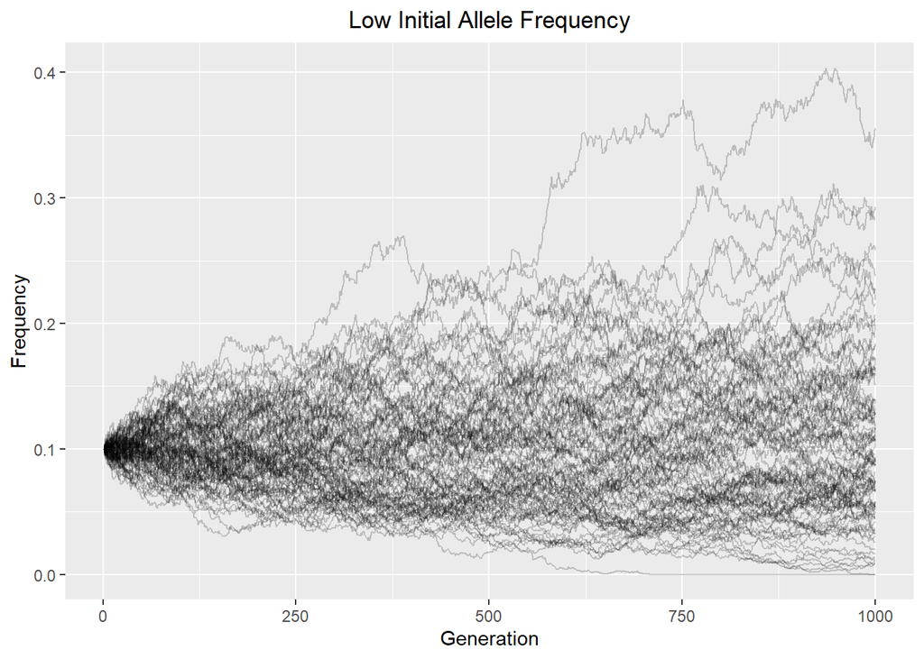

```r
#low p0
simdata <- trajectories(npops= 100, popsize = 10000, ngen = 1000, p0 = 0.1)
simdata_tidy <- pivot_longer(simdata, !Population, names_to = "Generation", names_prefix = "V", values_to = "Frequency")
simdata_tidy$Generation <- as.numeric(simdata_tidy$Generation)

low_p0 <-ggplot(simdata_tidy, aes(x = Generation, y = Frequency, group = Population)) +
  geom_line(alpha = 0.2) +xlab("Generation")
low_p0 + ggtitle("Low Initial Allele Frequency")+
  theme(plot.title = element_text(hjust = 0.5))
```

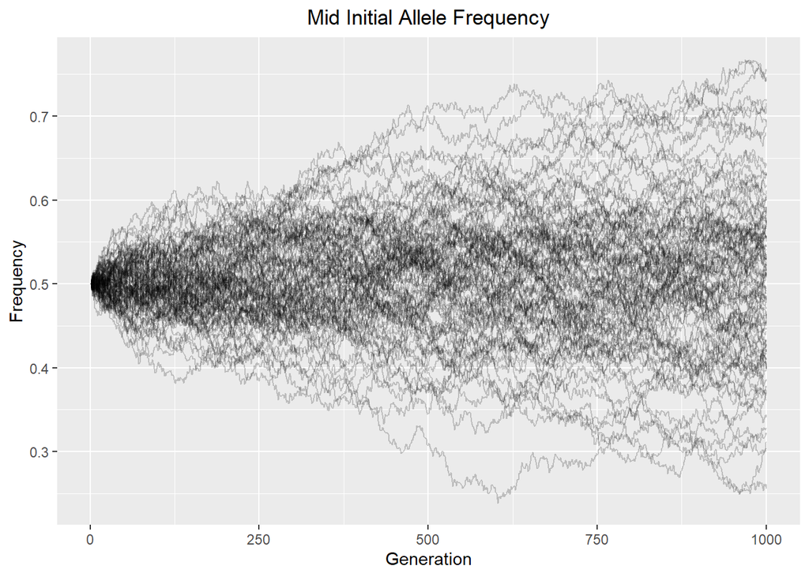

```r
#mid p0
simdata <- trajectories(npops= 100, popsize = 10000, ngen = 1000, p0 = 0.5)
simdata_tidy <- pivot_longer(simdata, !Population, names_to = "Generation", names_prefix = "V", values_to = "Frequency")
simdata_tidy$Generation <- as.numeric(simdata_tidy$Generation)

mid_p0 <-ggplot(simdata_tidy, aes(x = Generation, y = Frequency, group = Population)) +
  geom_line(alpha = 0.2) +xlab("Generation")
mid_p0 + ggtitle("Mid Initial Allele Frequency")+
  theme(plot.title = element_text(hjust = 0.5))
```

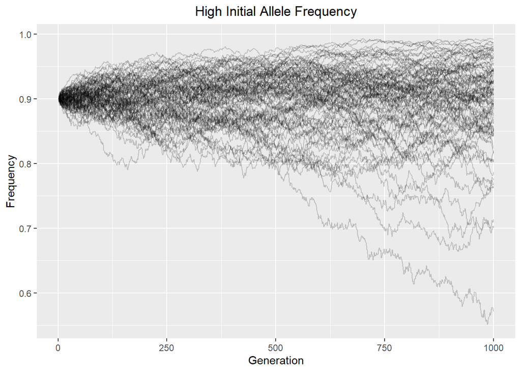

```r
#high p0
simdata <- trajectories(npops= 100, popsize = 10000, ngen = 1000, p0 = 0.9)
simdata_tidy <- pivot_longer(simdata, !Population, names_to = "Generation", names_prefix = "V", values_to = "Frequency")
simdata_tidy$Generation <- as.numeric(simdata_tidy$Generation)

high_p0 <-ggplot(simdata_tidy, aes(x = Generation, y = Frequency, group = Population)) +
  geom_line(alpha = 0.2) +xlab("Generation")
high_p0 + ggtitle("High Initial Allele Frequency")+
  theme(plot.title = element_text(hjust = 0.5))
```

### Number of Generations

Next, let’s vary the number of generations that our populations go through.

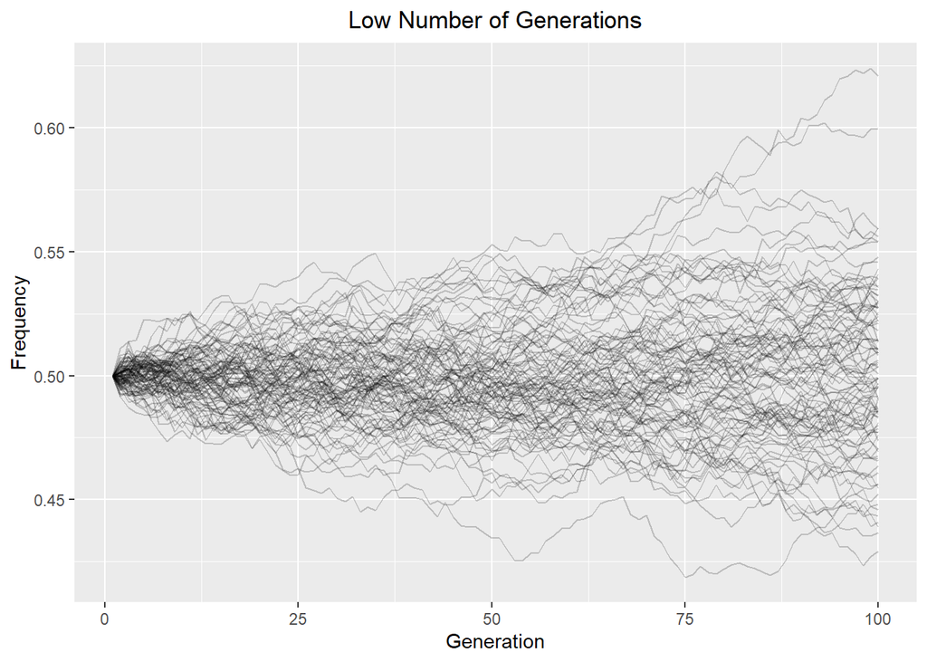

```r
#low ngen
simdata <- trajectories(npops= 100, popsize = 10000, ngen = 100, p0 = 0.5)
simdata_tidy <- pivot_longer(simdata, !Population, names_to = "Generation", names_prefix = "V", values_to = "Frequency")
simdata_tidy$Generation <- as.numeric(simdata_tidy$Generation)

low_ngen <-ggplot(simdata_tidy, aes(x = Generation, y = Frequency, group = Population)) +
  geom_line(alpha = 0.2) +xlab("Generation")
low_ngen + ggtitle("Low Number of Generations")+
  theme(plot.title = element_text(hjust = 0.5))
```

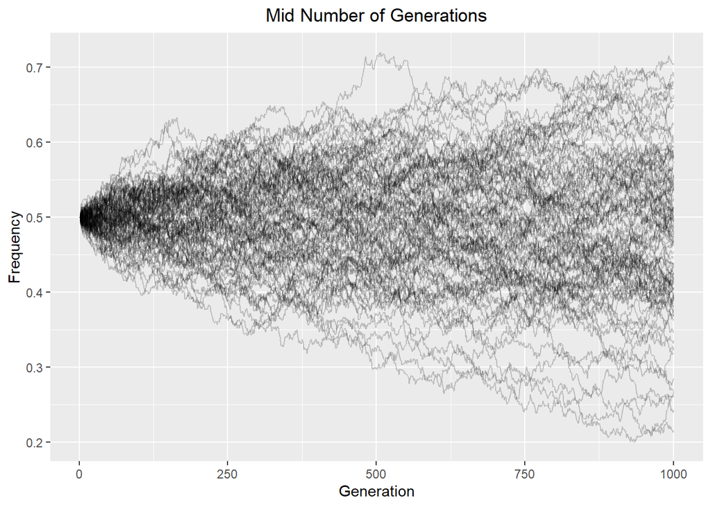

```r
#mid ngen
simdata <- trajectories(npops= 100, popsize = 10000, ngen = 1000, p0 = 0.5)
simdata_tidy <- pivot_longer(simdata, !Population, names_to = "Generation", names_prefix = "V", values_to = "Frequency")
simdata_tidy$Generation <- as.numeric(simdata_tidy$Generation)

mid_ngen <-ggplot(simdata_tidy, aes(x = Generation, y = Frequency, group = Population)) +
  geom_line(alpha = 0.2) +xlab("Generation")
mid_ngen + ggtitle("Mid Number of Generations")+
  theme(plot.title = element_text(hjust = 0.5))
```

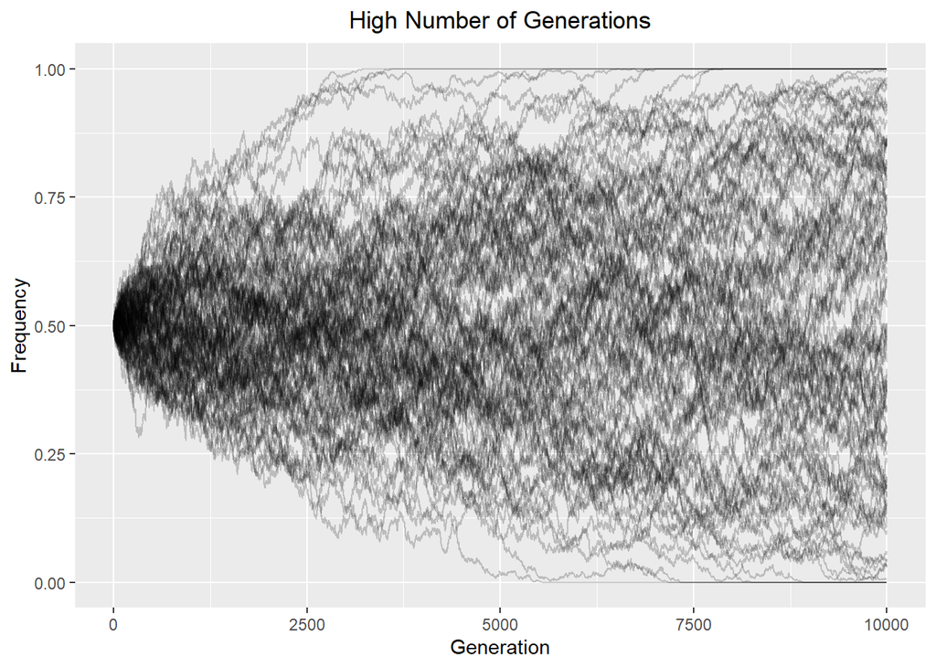

```r
#high ngen
simdata <- trajectories(npops= 100, popsize = 10000, ngen = 10000, p0 = 0.5)
simdata_tidy <- pivot_longer(simdata, !Population, names_to = "Generation", names_prefix = "V", values_to = "Frequency")
simdata_tidy$Generation <- as.numeric(simdata_tidy$Generation)

high_ngen <-ggplot(simdata_tidy, aes(x = Generation, y = Frequency, group = Population)) +
  geom_line(alpha = 0.2) +xlab("Generation")
high_ngen + ggtitle("High Number of Generations")+
  theme(plot.title = element_text(hjust = 0.5))
```

### Population Size

Finally, let’s vary our population size.

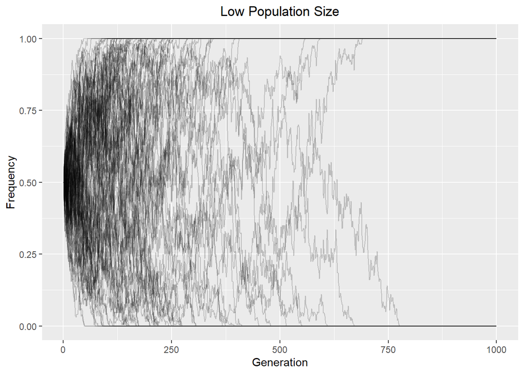

```r
#low popsize
simdata <- trajectories(npops= 100, popsize = 100, ngen = 1000, p0 = 0.5)
simdata_tidy <- pivot_longer(simdata, !Population, names_to = "Generation", names_prefix = "V", values_to = "Frequency")
simdata_tidy$Generation <- as.numeric(simdata_tidy$Generation)

low_popsize <-ggplot(simdata_tidy, aes(x = Generation, y = Frequency, group = Population)) +
  geom_line(alpha = 0.2) +xlab("Generation")
low_popsize + ggtitle("Low Population Size")+
  theme(plot.title = element_text(hjust = 0.5))
```

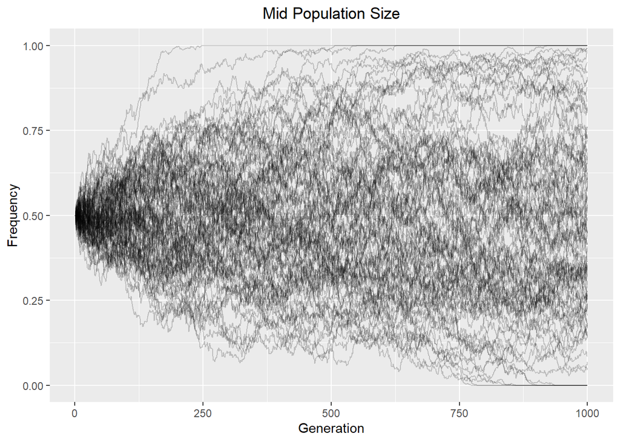

```r
#mid popsize
simdata <- trajectories(npops= 100, popsize = 1000, ngen = 1000, p0 = 0.5)
simdata_tidy <- pivot_longer(simdata, !Population, names_to = "Generation", names_prefix = "V", values_to = "Frequency")
simdata_tidy$Generation <- as.numeric(simdata_tidy$Generation)

mid_popsize <-ggplot(simdata_tidy, aes(x = Generation, y = Frequency, group = Population)) +
  geom_line(alpha = 0.2) +xlab("Generation")
mid_popsize + ggtitle("Mid Population Size")+
  theme(plot.title = element_text(hjust = 0.5))
```

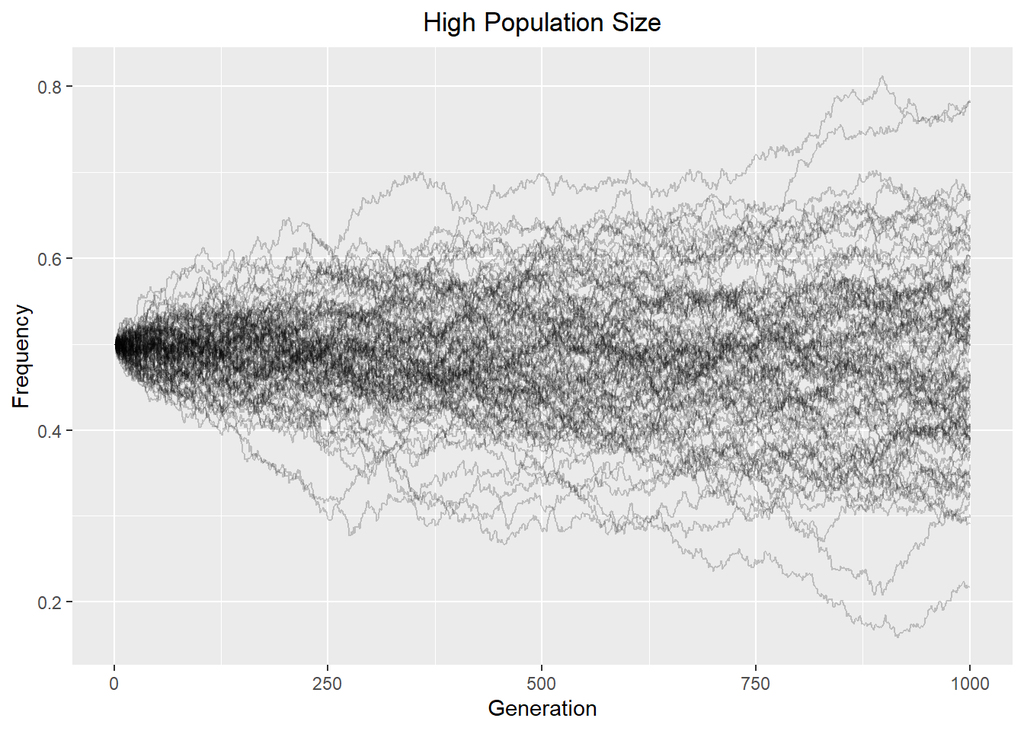

```r
#high popsize
simdata <- trajectories(npops= 100, popsize = 10000, ngen = 1000, p0 = 0.5)
simdata_tidy <- pivot_longer(simdata, !Population, names_to = "Generation", names_prefix = "V", values_to = "Frequency")
simdata_tidy$Generation <- as.numeric(simdata_tidy$Generation)

high_popsize <-ggplot(simdata_tidy, aes(x = Generation, y = Frequency, group = Population)) +
  geom_line(alpha = 0.2) +xlab("Generation")
high_popsize + ggtitle("High Population Size")+
  theme(plot.title = element_text(hjust = 0.5))
```

We can see that as we increase the population size, less and less populations go to extinction and fixation. Interestingly, at a low population size, it seems that the number of populations that either go to fixation, or go to extinction, are about equal. At a initial frequency of 50% this makes sense, as populations are initially equally as likely to go to fixation/extinction. How about at other initial frequencies?

## Genetic Drift - Changing More than One Variable

While the previous simulations have focused on what occurs when one variable is changed, and all others remain constant, we know that this rarely happens in real populations. Let’s see what happens when we change more than one variable.

NOTE: The code is adapted from https://stephens999.github.io/fiveMinuteStats/wright_fisher_model.html

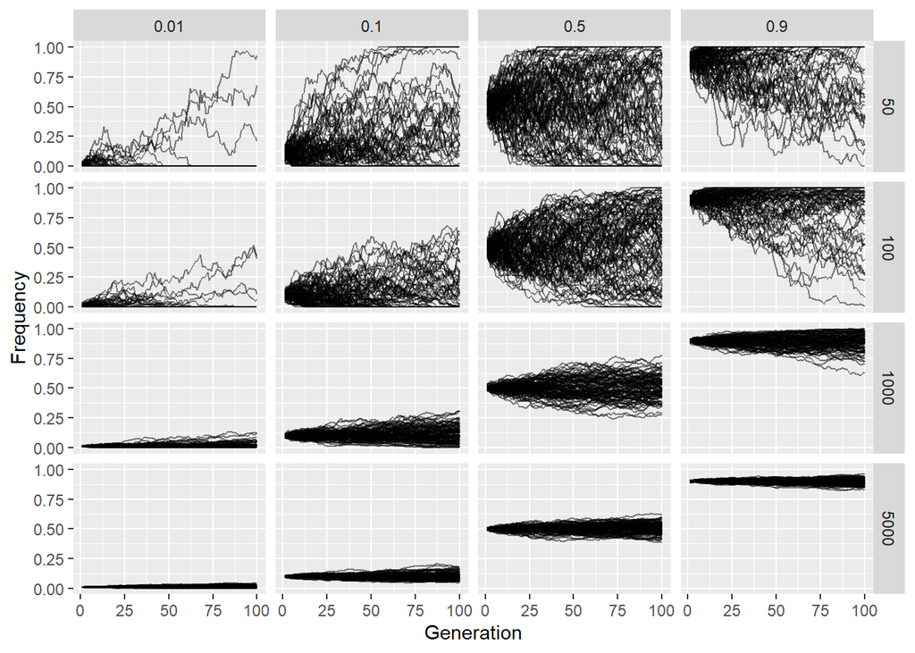

Here we see the result of varying the population size and initial frequency together. Number of generations could similarly be changed along with the other two variables; this was not included for conciseness (64 graphs would have been produced), but the code may be manipulated to show the result of changing number of generations with other parameters.

Overall, we see that initial frequency has a large impact on whether an allele becomes fixed or extinct. Without a high initial frequency, it is very unlikely a new allele that appears in a population will last without extraordinary conditions.

## Fixation

Next, let’s determine the relationship between the number of generations it takes on average to get an allele to fixation, and the population size.

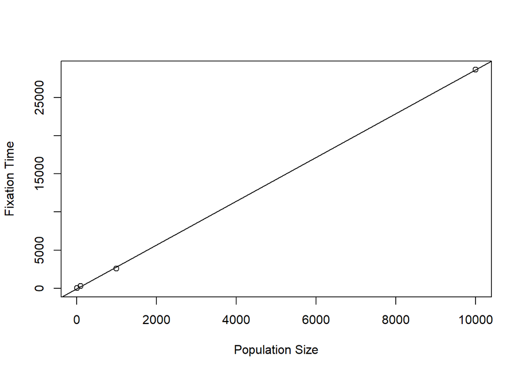

```r
population <- c(10, 100, 1000, 10000)
generations <- 100
matrix <- matrix(0,nrow=generations,ncol<-length(population))

for(i in 1:generations){
  fixation <- c()
  for(j in population){
    pA <- c()
    pA[1] <- 0.5
    k <- 1
    while ((pA[k] < 1) & (pA[k] > 0)) {
      pA[k+1] <- rbinom(n=1,size=2*j,prob=pA[k])/(2*j)
      k <- k+1
    }
    fixation <- c(fixation,k)
  }
  matrix[i,] <- fixation
}
means <- colMeans(matrix)
plot(population, means, xlab = "Population Size", ylab = "Fixation Time")
abline(lm(means~population))
```

From the graph, it seems that there is a linear correlation between population size and the number of generations it takes a new allele to reach fixation.